# A model of U.S. incarceration rates

Michelle Tschida

June, 2015

# Abstract

Incarceration rates in the U.S. vary by state and year. My goal was to build a model to explain the variability without using state or regional variables as predictors in the model. The data set included: U.S. incarceration rates for each state and year from 1978 to 2012, crime rates for each state and year from 1978 to 2012 and state demographics that were a snapshot in time. The original data set has 80 columns. The final model explains about 60% of the variation in incarceration rates. It used an AR(1) time correlation and state as a random variable. The independent variables in the model are: year, violent crime rate, property crime rate, % of people living below the poverty level and (violent crime rate) * (% living below the poverty level).

# Introduction

Data was gathered on U.S. incarceration rates. Within the U.S., there is state to state variability. Some states seem special or different and stand out as being more tough on crime or more lenient. Texas being a classic example. I was curious to find out if these states are really different or if they just have a slightly different set of circumstances, such as higher crime rates. The goal of this exercises was to see how much of the variation in U.S. state incarceration rates could be modeled with the non-regional variables that were on hand.

Execution totals were gathered as part of the data set. In depth analysis and modeling was not done. However, Appendix 5 contains several tables and graphs on execution rates.

# Materials & Methods

## Materials & Methods: The Data

Three data sets used in this analysis are:

The 80 columns are listed in Appendix 1. Here is a summary:  
* Incarceration rates is the rate per 100,000 people.  
* Executions total for that state and year.  
* U.S. census bureau data for each state that is a snapshot in time, mostly around 2010.  
* The crime rates are based on reported crimes in the U.S. and are considered representative of the crime in the area. Rates are the number of reported offenses per 100,000 population.  
* Violent crime and property crime are summaries of the other crime rates. So, for modeling one can either use the rolled up values or the more detailed crime rates, but not both.  
* The violent crime rate is the sum of the murder and non-negligent manslaughter rate, forcible rape rate, robbery rate, aggravated assault rate. violent crime rate= 100,000 * (murder and non-negligent manslaughter rate + forcible rape rate + robbery rate + aggravated assault rate)/population  
* The property crime rate is the sum of: burglary rate,larceny theft rate and motor vehicle theft rates. property crime rate= 100,000 * (burglary rate + larceny theft rate + motor vehicle theft rates)/population

2.**‘CrmYrUS’:** The data set CrmYrUS contains incarceration rates , executions and crime estimates for the total U.S. by year.

3.**‘qf_dd’:** This data set is the U.S. Census Bureau quick facts data dictionary. This gives the definitions and meanings of the fields from the U.S Census Bureau, which are cryptic.

The data was scraped from the internet from several sources. More information about where the data was obtained and how it was combined can be found in the file “Importing U.S. incarceration and execution data”. The web pages the data was scraped from are the following:  
The US Census Quick Facts: http://quickfacts.census.gov/qfd/download_data.html

Execution data: http://www.bjs.gov/content/dtdata.cfm#State/

Incarceration rates: http://www.bjs.gov/index.cfm?ty=nps

Estimated crime: http://www.bjs.gov/ucrdata/Search/Crime/State/RunCrimeStatebyState.cfm

## Materials & Methods: The Methods.

I prepared the data by doing some transformations and data reduction. The incarceration rate was skewed, so I transformed it using the natural log. All independent variables that were numbers, except for year, were standardized.

For the initial model, the independent variables were reduced from 79 to 16 by the following methods:  
- redundant and highly correlated variables were consolidated, - I tested to find variables that might be dominated by a few outliers  
- variables were set aside that had a weak relationship with incarceration rate.  
- I tried step-wise regression and Lasso, but they were unhelpful in reducing the set of independent variables further.

For modeling, I used generalized additive mixed models with incarceration rate as a response and individual states as a random variable. I accounted for temporal auto-correlation with an AR(1) structure. I choose between models based on p-value of the variables, my knowledge of the fields, the AIC, the BIC.

The packages I used for data preparation are: stats::cor, psych::pairs.panels, graphics::hist, ggplot2::ggplot, a function I wrote called get.top.corr. The mgcv::gamm package was used for modeling.

# Results

## Results: Data Exploration

This map is an example of the regional variations for incarceration rate. Although there are some exceptions, the southern states tend to have higher incarceration rates than many of the northern states.

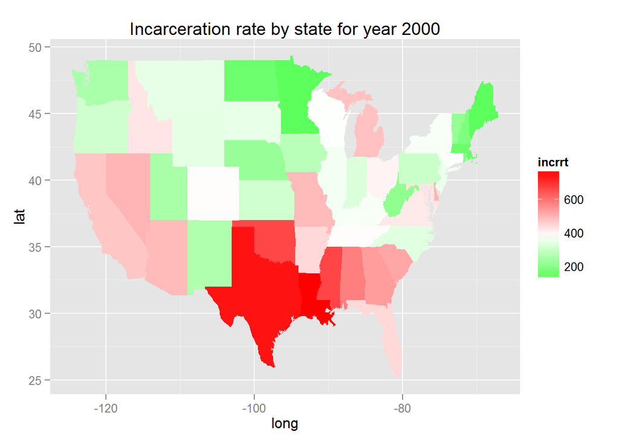

The plots below show that incarceration rates are skewed and that there is a strong time trend. I used the natural log of the incarceration rate for modeling and many diagnostics.

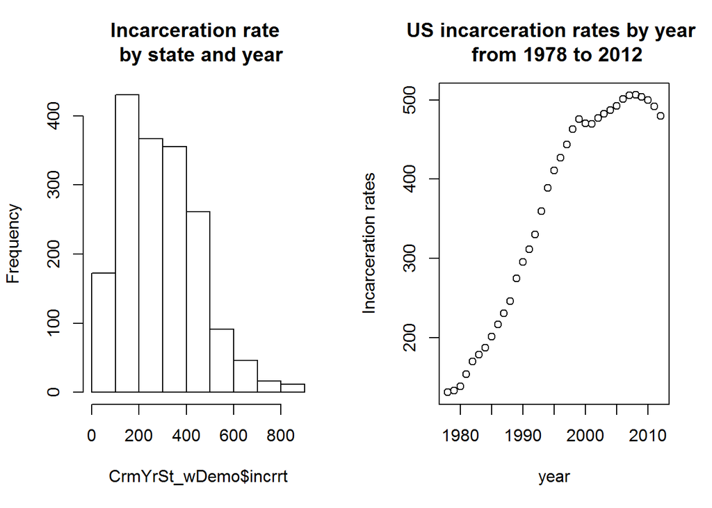

## Results: Reducing columns for initial modeling and data preperation.

Several tools were used to suggest potential candidates of variables to remove for initial modeling. When a variable was found by one of these tools, it was investigated and a decision was made to keep or toss the variable. This helped to reduce the data set from about 79 independent variables to 16 to begin the modeling process.

#### Removing redundant and highly correlated variables

I wrote a function called get.top.corr to help find variables that were highly correlated to each other. Inputs to get.top.corr are a correlation threshold and a data frame of numeric columns. The function takes the first column of the data frame and finds all other columns that have a correlation above the threshold. These names of these variables are put in a group with an identifier, a new data frame is created without these columns, and the process is repeated until data frame has 0 columns. The grouped variable names are output from the function. The code for get.top.corr is in Appendix 2.

Example: Eleven variables were output from get.top.corr that were correlated with population >= 95%. Population was chosen to represent the other variables because it is yearly data and many of the others are snapshots in time. These variables are listed in Appendix 3 B.

#### Checking for variables that are dominated by one or two outliers

Any variable that had a maximum standardized z-score >7 was examined to see if it was dominated by a few outliers, which might make it unhelpful for modeling. Histograms and plots of suspect variables were examined to determine if the high values were outliers or on a smooth continuum. Nothing stood out in the remaining variables enough to justify removing them from the set of variables to try in the model.

To decide the z-score threshold, first a data frame of random z-scores with mean 0 and standard deviation of 1 were generated. The data frame had the same dimensions as the data set. The maximum z-score was computed for each column. The median of maximum z-score’s was about 3.5. Two times 3.5 is 7, which was the z-score threshold that made a variable a candidate for removal due to extreme outliers.

#### Removing variables with a low correlation with incarceration rate for the initial modeling.

Variables with a low correlation score with incarceration rate was found. Of those variables with low correlation scores, the plots were examined to check for potential non-linear relationships. Independent variables that had a weak relationship with incarceration rate were candidates to be removed for the first round of modeling. The variables that were removed are listed in Appendix 3 part D.

The packages that were used are: stats::cor, ggplot2::ggplot.

#### Choosing initial variables from the crime data

The violent crime rate is the sum of: murder and non negligent manslaughter rate, forcible rape rate, robbery rate and aggravated assault rate. The property crime rate the sum of: burglary rate,larceny theft rate and motor vehicle theft rates. So, either the rolled up values or the more detailed rates should be used for modeling, but not both. Initially, just the violent crime rate and property crime rate was used. The correlation between the violent crime rate and property crime rate is 0.5954204 .

The following graphs show the correlation structure and shape of the variables that make up violent crime rate and the property crime rate.

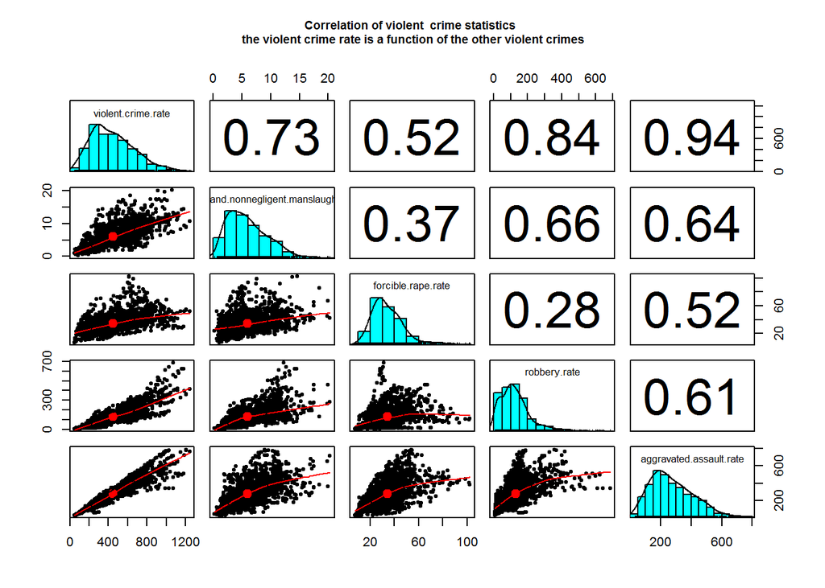

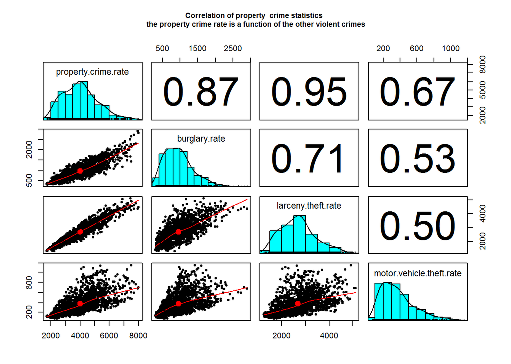

#### The data set for initial modeling.

The data set started out with 80 variables. After all the reductions, the dimensions are 1750, 18.  
Some notes:  
* There are 16 independent variables to model with initially. * Incrrt is the response variable that was modeled.  
* State was a random variable in the model.  
* With the exception of year, each of the independent variables were standardized by subtracting the average and dividing by the standard deviation.

**A list of the variables in the reduced data set for the initial model.**

| data_item.lower | item_description |
| --- | --- |
| age295213 | Persons under 18 years, percent, 2013 |
| bza115213 | Private nonfarm employment, percent change, 2012-2013 |
| edu635213 | High school graduate or higher, percent of persons age 25+, 2009-2013 |
| edu685213 | Bachelor’s degree or higher, percent of persons age 25+, 2009-2013 |
| illiteracy | NA |
| inc110213 | Median household income, 2009-2013 |
| incrrt | NA |
| lifeexp | NA |
| pop060210 | Population per square mile, 2010 |
| population | NA |
| property.crime.rate | NA |
| pvy020213 | Persons below poverty level, percent, 2009-2013 |
| rhi125213 | White alone, percent, 2013 |
| rhi225213 | Black or African American alone, percent, 2013 |
| rtn131207 | Retail sales per capita, 2007 |
| state | NA |
| violent.crime.rate | NA |
| year | NA |

## Results: Choosing a model

The package mgcv::gamm was used for modeling, although nlme::gls worked as well. Variables in the model were reduced by several stages in a process that was something like backward selection. Variables were kept and eliminated was based on p-values, the AIC, the BIC and my understanding of the data.

I ended up with 3 competing models. Each used a spline function for year, a time auto-regression and used state as a random variable. The only difference is in the fixed terms.

Model5 had 5 fixed terms and an interaction. Model4 had 4 fixed terms. Model4 had the same terms as model5 minus median income. Model3 had 3 fixed terms. Model3 was model5 minus median income and property crime rate.

Model3: ln(incarceration rate)~ year(spline) + % below the poverty level + violent crime rate + AR(1) time auto regression.

Every term in the model 5 is significant with all the p-values < 0.05. However, income and poverty have a correlation of -0.8508991. The property crime rate is correlated with the violent crime rate at 0.5954204 and the year at -0.5150944.

**Correlations for the terms in the final model.**  
inc110213 is median income. pvy020213 is % living below the poverty level

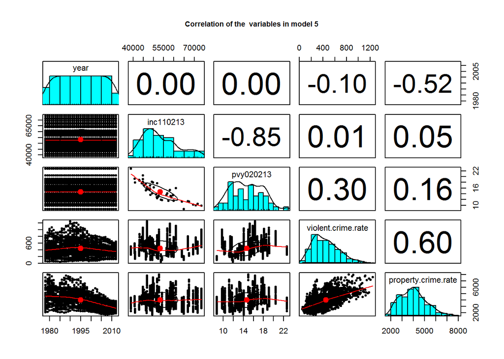

**Plots of incarceration rate with each final variables in model 5.**  
inc110213 is median income. pvy020213 is % living below the poverty level

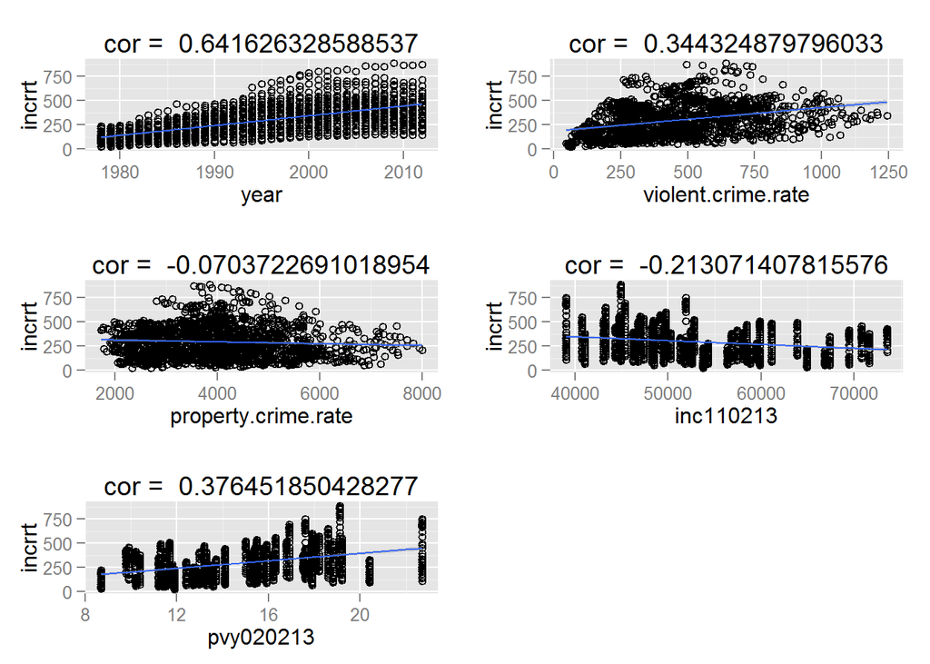

**Comparing the AIC and BIC for the models.** Lower is better for both AIC and BIC. So, the results are mixed.

```
##            Model df       AIC       BIC  logLik   Test  L.Ratio p-value
## model5$lme     1 10 -4837.101 -4782.427 2428.55
## model4$lme     2  9 -4833.280 -4784.074 2425.64 1 vs 2 5.820926  0.0158
```

```
##            Model df       AIC       BIC   logLik   Test  L.Ratio p-value
## model5$lme     1 10 -4837.101 -4782.427 2428.550
## model3$lme     2  7 -4806.675 -4768.404 2410.338 1 vs 2 36.42577  <.0001
```

```
##            Model df       AIC       BIC   logLik   Test  L.Ratio p-value
## model4$lme     1  9 -4833.280 -4784.074 2425.640
## model3$lme     2  7 -4806.675 -4768.404 2410.338 1 vs 2 30.60484  <.0001
```

## Results: The final model

Model 4 was chosen as the final model.

**The Anova**

|  | Estimate | Pr(>\|t\|) |
| --- | --- | --- |
| (Intercept) | 5.5093153 | 0.0000000 |
| violent.crime.rate | 0.0232420 | 0.0229214 |
| property.crime.rate | -0.0431194 | 0.0000001 |
| pvy020213 | 0.2336503 | 0.0000023 |
| violent.crime.rate:pvy020213 | -0.0165395 | 0.0505460 |

**Model diagnostics for goodness of fit.**

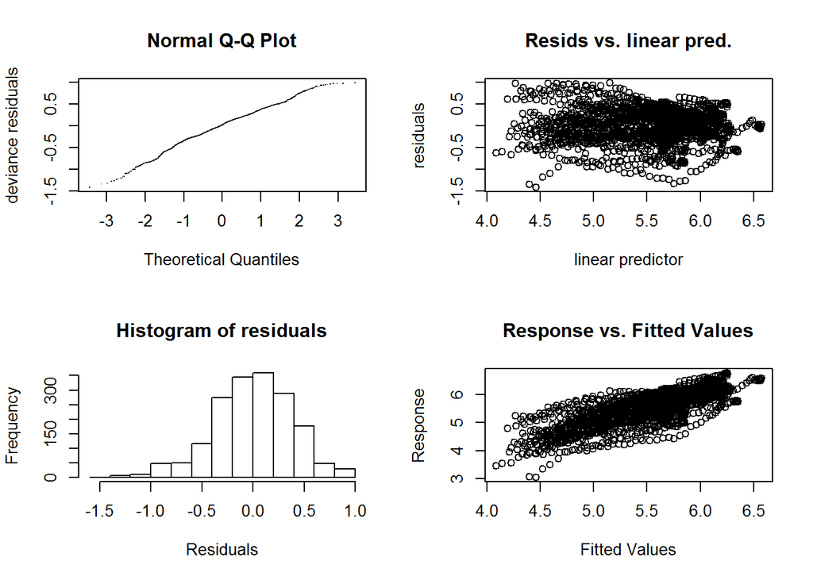

**Some diagnostic graphs for AR(1) .**  
The graphs with AR(1) look better.

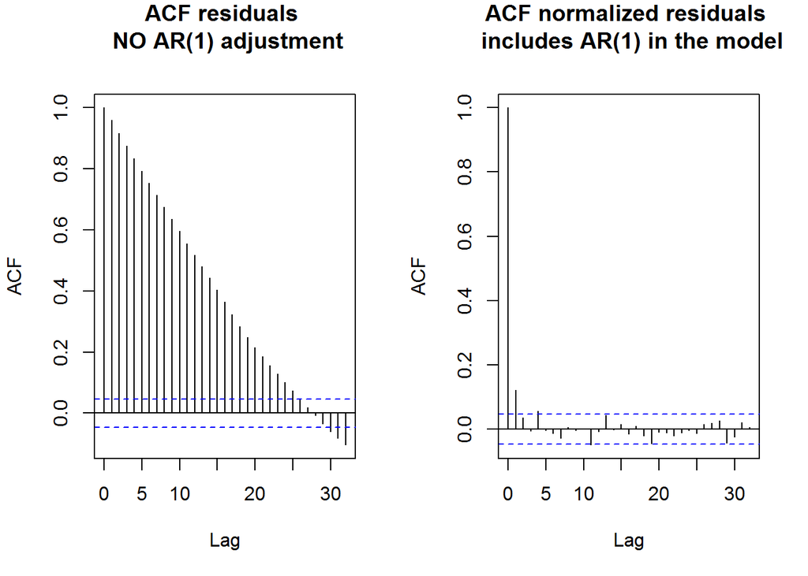

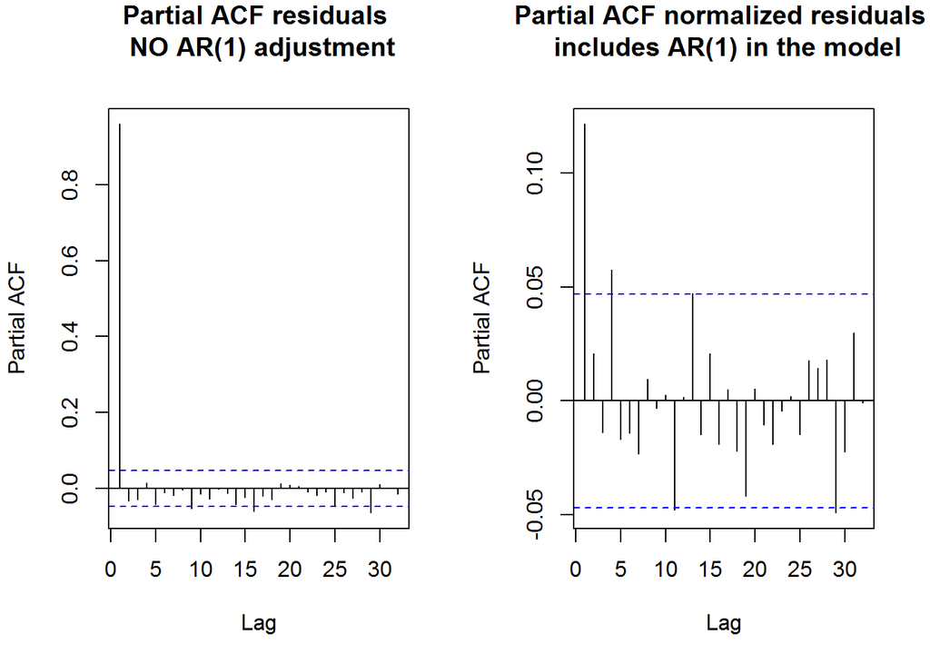

**Plots of predicted vs actual for a few states.**

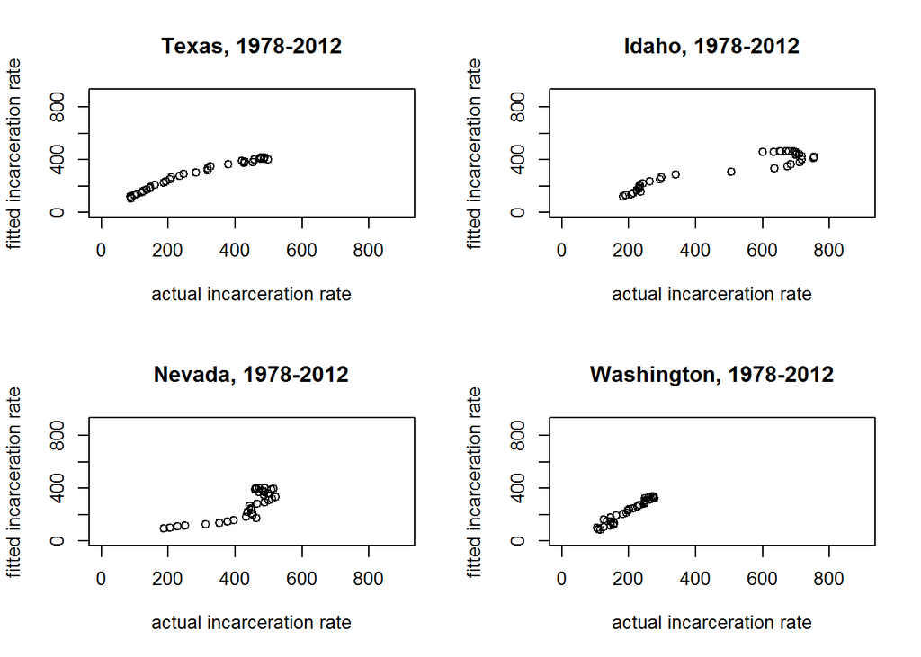

**Plot of predicted vs actual for all states and years**

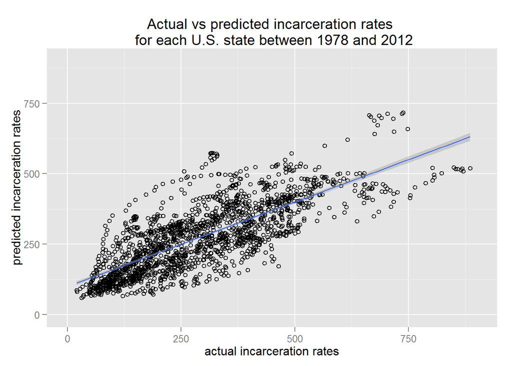

**Maps of the actual vs fitted values for the year 2000.** Maps for the years 1980 and 2012 are in Appendix 4.

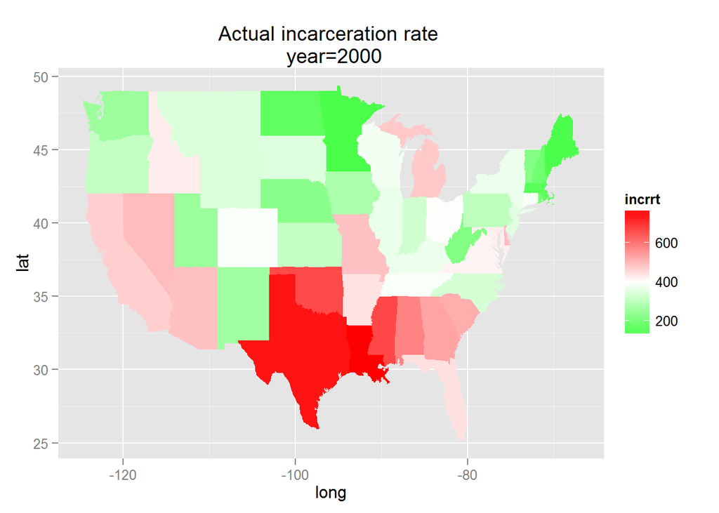

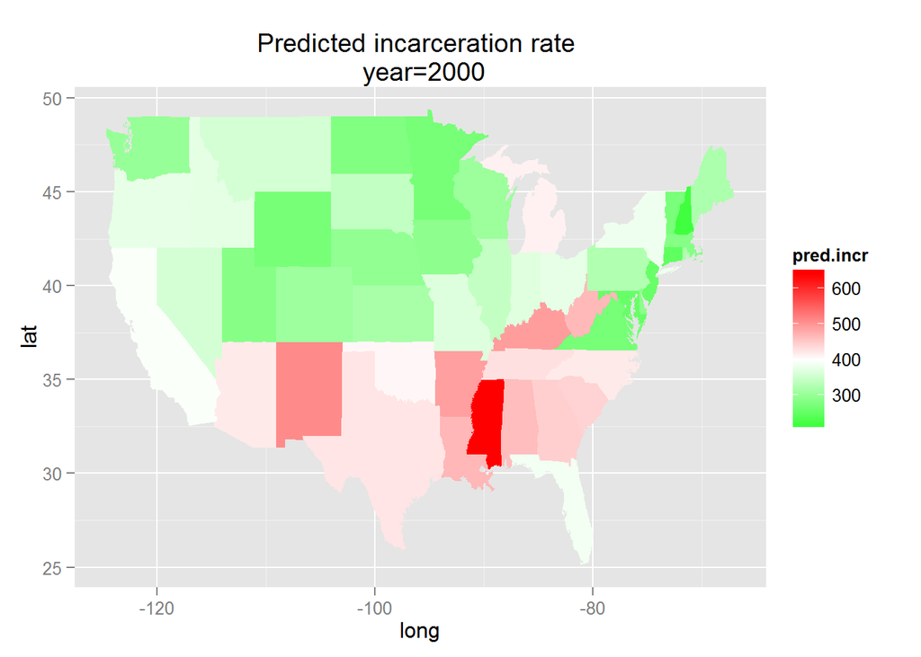

# Discussion

The final model explains about 60% of the variation, which leaves about 40% of the variation of incarceration rates by state unexplained. The model accurately predicts that the north tends to have lower incarceration rates than the south. It also accurately predicted that Michigan has higher incarceration rates than many of the northern states. However, the model was inaccurate for other states such as Virginia, West Virginia, Kentucky, Idaho, California and Nevada. Although it predicted that incarceration rates were higher than usual for Texas, the model under predicted those rates.

The coefficients show the direction and strength of the variable. Of course, since this is observational data, we should think in terms of correlation rather than causation.

In the model, states that have a higher percent of people living in poverty tend to have higher incarceration rates. Although income was taken out of the final model, it was one of the last variables to be removed. It would be interesting to investigate putting income into the model and checking the variance inflation factor since income is correlated with poverty. It is also possible that there might be another variable that could replace both median income and poverty, such a measure of income inequality or the % of people living in urban areas.

In the final model, incarceration rates tend to be higher in states that have more violent crime, but property crime has a negative effect on the predicted incarceration rate. More exploration is needed to understand this, which might lead to future adjustments of the model. It would be interesting to substitute burglary, larceny theft and motor vehicle theft for property crime rate in the model.

The property crime rate has a correlation of 0.5954204 with the violent crime rate and a correlation of -0.5150944 with year. The variance inflation factor could help determine if the multicollinearity is high enough to be a problem. If its too high something could be done such as removing property crime somehow combining variables such as using principal components or using factor analysis.

The were removed because of low correlation scores with the incarceration rate can be reconsidered in next phase of modeling. Jacob Shimmering gives some good reasons to do this in the following blog post: http://www.r-bloggers.com/stop-using-bivariate-correlations-for-variable-selection/

Some ideas for more data:

- Because U.S. census demographic data was useful for modeling, some fields could be updated to change with time instead of just being a snapshot in time.
- Gathering Federal and state policy information and changes in laws.
- State Budgets for things such as law enforcement and prisons. Some budget information, along with lots of other data, can be found on these pages:  
  http://www.bjs.gov/index.cfm?ty=daa  
  http://www.bjs.gov/content/dtdata.cfm

# Appendix

## Appendix 1: Data sets and initial variables

**The main data sets are:**

- **‘CrmYrUS’:** Incarceration rates , executions and crime estimates for the total US by year.
- **‘CrmYrSt_wDemo’:** This data set contains Incarceration rates, Execution totals, Estimated Crime by year along with state demographics from the Us Census Bureau Quick Facts. The quick facts was from 2010, so the demographics for each state/year combination will be the same. This data set is a left join of CrmYrSt and StateDemo.
  - **‘CrmYrSt’:** Incarceration rates , executions and crime estimates by US state by year. This data set is a subset of CrmYrSt_wDemo.
  - **‘StateDemo’:** US State Demographics from the R state data files and the US Census Bureau 2010 Quick facts, which has 53 fields. This data set is a subset of CrmYrSt_wDemo.
- **‘qf_dd’:** US Census Bureau quick facts data dictionary, which gives the definition and meaning of the fields.

**A list of initial variables with some definitions:**

The fields listed below were collected for each year and US state from 1978 to 2012. Some notes:  
* Incarceration rates are per 100,000 people.  
* Execution rates are total for each state and year combination.  
* Crime rates are per 100,000 people. These are a subset of all reported crimes. These crimes are considered to be serious crimes and are thought to be representative of overall crime in the area.  
* The violent crime rate is a combination of the following: murder and non-negligent manslaughter rate, forcible rape rate, robbery rate, and aggravated assault rate.  
* The property crime rate is a combination of the following: Burglary rate, larceny theft rate, motor vehicle theft rate.  
* States are U.S. states. District of Columbia was removed because some complete data fields were missing. Crime data stopped being collected at a certain year and was rolled up into federal statistics. When it was reported, crime data for the District of Columbia seemed very high.

```
##  [1] "state"
##  [2] "year"
##  [3] "incrrt"
##  [4] "executions"
##  [5] "population"
##  [6] "violent.crime.rate"
##  [7] "murder.and.nonnegligent.manslaughter.rate"
##  [8] "forcible.rape.rate"
##  [9] "robbery.rate"
## [10] "aggravated.assault.rate"
## [11] "property.crime.rate"
## [12] "burglary.rate"
## [13] "larceny.theft.rate"
## [14] "motor.vehicle.theft.rate"
```

The fields below were collected from the R state file. These fields do not vary year to year.

```
##  [1] "state.name.lower" "fips"             "county.name"
##  [4] "state.division"   "state.region"     "state.abb"
##  [7] "income"           "illiteracy"       "lifeexp"
## [10] "murder"           "hsgrad"           "frost"
## [13] "area"             "pst045214"
```

Below are the fields that were used from the Quick Facts from the US Census Bureau. Most of this data is a snapshot in time. So, while it varies state to state, it is static year to year.

```
##  [1] Population, 2014 estimate
##  [2] Population, 2013 estimate
##  [3] Population, 2010 (April 1) estimates base
##  [4] Population, percent change - April 1, 2010 to July 1, 2014
##  [5] Population, percent change - April 1, 2010 to July 1, 2013
##  [6] Population, 2010
##  [7] Persons under 5 years, percent, 2013
##  [8] Persons under 18 years, percent, 2013
##  [9] Persons 65 years and over, percent, 2013
## [10] Female persons, percent, 2013
## [11] White alone, percent, 2013
## [12] Black or African American alone, percent, 2013
## [13] American Indian and Alaska Native alone, percent, 2013
## [14] Asian alone, percent, 2013
## [15] Native Hawaiian and Other Pacific Islander alone, percent, 2013
```

[output cut: 39 more lines]

## Appendix 2: The get.top.corr function.

```r
#A function to find an initial list of variables that are highly correlated

#cor.thrsh  is the correlation threshhold
#c.data.set  is the data set of numeric variables

get.top.corr <-function(cor.thrsh=0.95,c.data.set){
  ds<- data.frame()

while(dim(c.data.set)[2]>0){
cr <- as.data.frame(cor(c.data.set,use="pairwise.complete.obs"))
nms <- (names(cr)[cr[1]>=abs(cor.thrsh)])
cor.mtx <- as.data.frame(cbind(nms,names(cr[1]),length(nms),cor.thrsh))
ds<- rbind(ds,cor.mtx)
 c.data.set<- subset(c.data.set,select= !names(c.data.set) %in% nms)
}

names(ds)<-c("name","grp","nvar","cor")

ds2 <- merge(x=ds[! ds$nvar %in% c("1"),],y=qf_dd,by.x="name",by.y="data_item.lower",all.x=TRUE)
return(ds2)
}
```

## Appendix 3: Variable reduction for initial modeling.

**A.** These variables were removed either because the information was redundant or it was not needed/wanted for this analysis: income, murder, hsgrad, area, fips,state.name.lower ,state.abb, frost,county.name,state.division,state.region , frost, executions

Keep: Population (yearly)  
* Private nonfarm establishments, 2013  
* Private nonfarm employment, 2013  
* Households, 2009-2013  
* Housing units, 2013  
* Nonemployer establishments, 2012  
* Population, 2010  
* Population, 2010 (April 1) estimates base  
* Population, 2013 estimate  
* Population, 2014 estimate  
* Retail sales, 2007 ($1,000)  
* Total number of firms, 2007

Keep: Population, percent change - April 1, 2010 to July 1, 2013  
* Population, percent change - April 1, 2010 to July 1, 2014

Keep: Black or African American alone, percent, 2013__  
* Black-owned firms, percent, 2007

Keep: Asian alone, percent, 2013 * Asian-owned firms, percent, 2007

Keep: Native Hawaiian and Other Pacific Islander alone, percent, 2013  
* Two or More Races, percent, 2013  
* Native Hawaiian- and Other Pacific Islander-owned firms, percent, 2007

Keep: WTN220207 Merchant wholesaler sales  
* AFN120207 Accommodation and food services sales  
* BPS030213 Building permits  
* MAN450207 Manufacturers shipments  
* VET605213 Veterans

Keep: RHI725213 Hispanic or Latino, percent, 2013  
* SBO415207 Hispanic-owned firms, percent, 2007

Keep: RHI325213 American Indian and Alaska Native alone, percent, 2013  
* SBO115207 American Indian- and Alaska Native-owned firms, percent, 2007

Keep: POP815213 Language other than English spoken at home, pct age 5+, 2009-2013  
* POP645213 Foreign born persons, percent, 2009-2013

Keep: RHI525213 Native Hawaiian and Other Pacific Islander alone, percent, 2013  
* RHI425213 Asian alone, percent, 2013

**D.** The following variables were removed due to a low correlation with incarceration rate.

[output not shown]

| age135213 | age775213 | hsd310213 | hsg096213 | hsg445213 | hsg495213 |
| --- | --- | --- | --- | --- | --- |
| 0.1727343 | -0.1489238 | 0.2240916 | -0.1584848 | -0.0992492 | -0.1849465 |

| inc910213 | lfe305213 | lnd110210 | pop715213 | pop815213 | pst120213 |
| --- | --- | --- | --- | --- | --- |
| -0.2348663 | 0.1210781 | 0.1239766 | -0.1799366 | 0.0742977 | 0.0962411 |

| rhi325213 | rhi525213 | rhi725213 | sbo015207 | sex255213 | wtn220207 |
| --- | --- | --- | --- | --- | --- |
| 0.0265423 | -0.059285 | 0.1349282 | 0.1185395 | 0.1332183 | 0.1568303 |

## Appendix 4: Maps of Predicted vs Actualincarceration rates for 1980 and 2012.

[figure not shown]

```r
multiplot(actual_incr1980, actual_incr2012, pred_incr1980, pred_incr2012, cols=2)
```

## Appendix 5: A few graphs and tables of total executions by state.

The total executions by state between 1978 and 2012. States not listed had 0 executions for all of those years.

|  | state | executions |
| --- | --- | --- |
| 43 | Texas | 492 |
| 46 | Virginia | 109 |
| 36 | Oklahoma | 102 |
| 9 | Florida | 74 |
| 25 | Missouri | 68 |
| 1 | Alabama | 55 |
| 10 | Georgia | 52 |
| 35 | Ohio | 49 |
| 33 | North Carolina | 43 |
| 40 | South Carolina | 43 |
| 3 | Arizona | 34 |
| 18 | Louisiana | 28 |
| 4 | Arkansas | 27 |
| 24 | Mississippi | 21 |
| 14 | Indiana | 20 |
| 8 | Delaware | 16 |
| 5 | California | 13 |
| 13 | Illinois | 12 |
| 28 | Nevada | 12 |
| 42 | Tennessee | 6 |
| 44 | Utah | 6 |
| 20 | Maryland | 5 |
| 47 | Washington | 5 |
| 12 | Idaho | 3 |
| 17 | Kentucky | 3 |
| 26 | Montana | 3 |
| 27 | Nebraska | 3 |
| 38 | Pennsylvania | 3 |
| 41 | South Dakota | 3 |
| 37 | Oregon | 2 |
| 6 | Colorado | 1 |
| 7 | Connecticut | 1 |
| 31 | New Mexico | 1 |
| 50 | Wyoming | 1 |

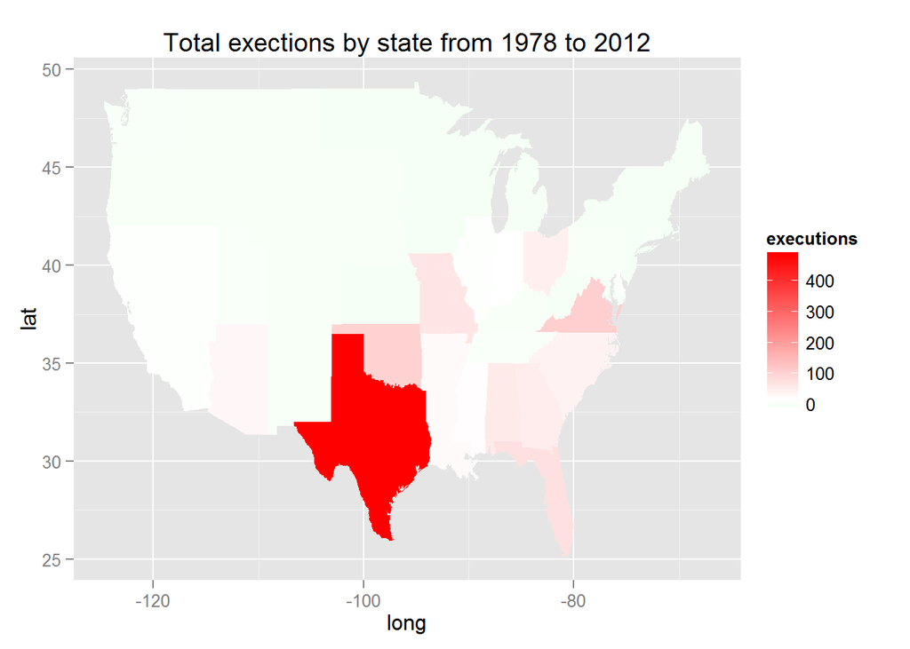

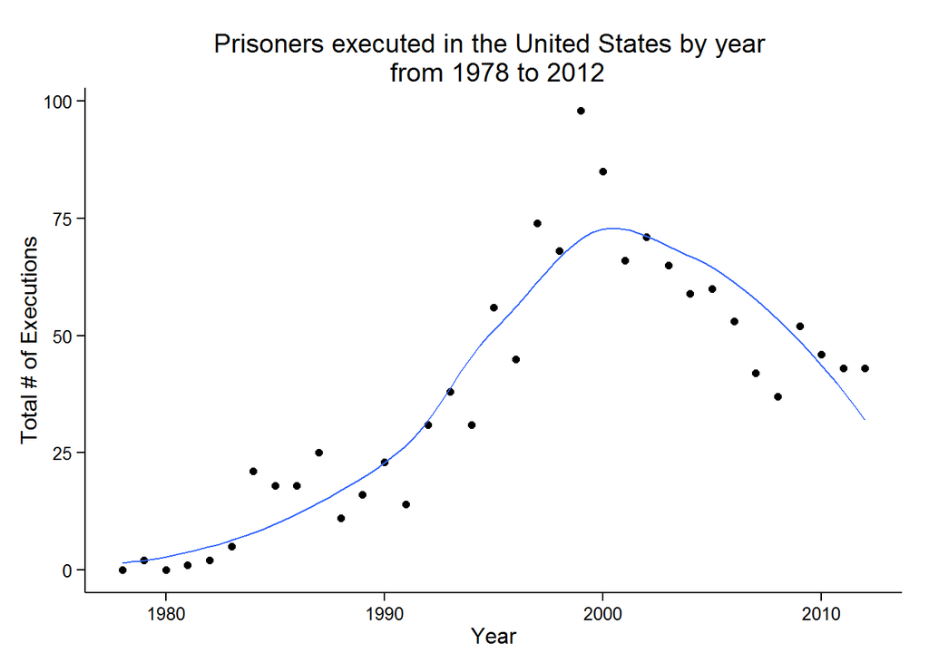